# RNA-Ribo divergence conditioned on RNA-Protein divergence

Author: Joyce Hsiao

Last updated: 2015-08-21 00:32:25

```r
library(Biobase)

## Set working directories
dir <- "../"
figdir <- file.path(dir,"figures")
rdadir <- file.path(dir,"rdas")
datadir <- file.path(dir, "data")

## Use broman package for colors
require(broman)
crayon <- brocolors("crayons")

## Load customized packages
require(devtools)
require(Humanzee)
```

# Goal

We investigate protein divergence relative to RNA divergence and consider if attenuation at the protein level is more likely to be associated with attenuation at the RNA level, and if enhancement at the protein level is more likely to be associated with enhancement at the RNA level.

# Definitions

```r
## Load rdas of LRT results and compute fold change estimates using
## RPKM values before normalization.

## load LRT results of RNA vs. Ribo divergence
load(file.path(rdadir,"TEnew.rda"))

## load LRT results of RNA vs. Protein divergence
load(file.path(rdadir,"rnapro.rda"))

## load LRT results of DE analysis
load(file.path(rdadir,"DE.rda"))


## Compute fold changes based on un-normalized data
## from the object eSetRRP.log2 in eSetRRP.rda
load( file.path(rdadir,"eSetRRP.rda") )

eSet.temp <- eSetRRP.log2[ ,eSetRRP.log2$species!="rhesus"]

fc.mat <- lapply( seq_along( c("human","chimp") ), function(i) {
  ii <- eSet.temp$species == c("human","chimp")[i]
  eSet.tt <- eSet.temp[, ii]
  emat <- lapply( seq_along( c("ribo","rna","protein") ), function(j) {
    jj <- eSet.tt$seqData == c("ribo","rna","protein")[j]
    rowMeans( exprs(eSet.tt[, jj] ), na.rm=TRUE )
  })
  emat <- do.call(cbind, emat)
  colnames(emat) <- c("ribo","rna","protein")
  return( data.frame(emat) )
})
names(fc.mat) <- c("human","chimp")

dmat_unnormed <- data.frame( ribo = fc.mat$human$ribo-fc.mat$chimp$ribo,
                             rna = fc.mat$human$rna-fc.mat$chimp$rna,
                             pro = fc.mat$human$protein-fc.mat$chimp$protein )

xy.rnapro <- data.frame( rna = dmat_unnormed$rna,
                         pro = dmat_unnormed$pro )
xy.riborna <- data.frame( rna = dmat_unnormed$rna,
                          ribo = dmat_unnormed$ribo )
xy.ribopro <- data.frame( ribo = dmat_unnormed$ribo,
                          pro = dmat_unnormed$pro )
```

# Gene classification

## RNA vs. Ribo divergence

```r
## Genes with sig. human/chimp difference in divergence between RNA and Ribo
ii_sig_rnaribo <- res.riborna$int.qval < .01

## Genes with sig. human/chimp difference in RNA levels
ii_sig_RNA_DE <- rnaRes.Q$qval < .01

## Genes with sig. human/chimp difference in Ribo levels
ii_sig_Ribo_DE <- riboRes.Q$qval < .01


## Category 1 - Enhanced divergence, criteria are as follows
## a) Sig. RNA vs. Ribo difference, AND
## b) Sig. DE at RNA level, AND
## c) ( abs(RNA FC) < abs(Ribo FC) ) AND ( RNA FC * Ribo FC > 0)
ii_riboGTrna <- (ii_sig_rnaribo) & ii_sig_RNA_DE &
                ( (abs(xy.riborna$ribo) > abs(xy.riborna$rna)) &
                  (xy.riborna$rna * xy.riborna$ribo > 0 ) )


## Category 2 - Attenuated divergence, criteria are as follows
## a) Sig. RNA vs. Ribo diff., AND
## b) Sig. DE at RNA level, AND
## c) ( abs(RNA FC) > abs(Ribo FC) ) AND ( RNA FC * Ribo FC < 0)
ii_rnaGTribo <- (ii_sig_rnaribo) & ii_sig_RNA_DE &
                ( (abs(xy.riborna$rna) > abs(xy.riborna$ribo) ) |
                  (xy.riborna$rna * xy.riborna$ribo < 0) )


## Category 3, Pseudo enhacement, criteria are as follows
## a) Sig. RNA vs. Ribo diff., AND
## b) No sig. DE at RNA level, AND
## c) Sig. DE at Ribo level
ii_null_rnaGTribo <- ii_sig_rnaribo & !ii_sig_RNA_DE & ii_sig_Ribo_DE


## Category 4, Null divergence, criteria are as follows
## a) Sig. RNA vs. Ribo diff., AND
## b) No sig. DE at RNA level, AND
## c) No sig. DE at Ribo level
ii_null_rnaNULLribo <- ii_sig_rnaribo & !ii_sig_RNA_DE & !ii_sig_Ribo_DE


Ribo_refmat <- rbind.data.frame(attenuated = sum(ii_rnaGTribo),
                                   enhanced = sum(ii_riboGTrna),
                                   null_enhanced = sum(ii_null_rnaGTribo),
                                   null = sum(ii_null_rnaNULLribo) )
colnames(Ribo_refmat) <- "# genes"
kable(Ribo_refmat)
```

|  | # genes |
| --- | --- |
| attenuated | 119 |
| enhanced | 22 |
| null_enhanced | 222 |
| null | 115 |

## RNA vs. Protein divergence

```r
## Genes with sig. human/chimp difference in divergence between RNA and protein
ii_sig_rnapro <- res.rnapro$int.qval < .01

## Genes with sig. human/chimp difference in RNA levels
ii_sig_RNA_DE <- rnaRes.Q$qval < .01

## Genes with sig. human/chimp difference in Protein levels
ii_sig_Pro_DE <- massRes.Q$qval < .01


## Category 1 - Enhanced divergence, criteria are as follows
## a) Sig. RNA vs. Protein difference, AND
## b) Sig. DE at RNA level, AND
## c) ( abs(RNA FC) < abs(Protein FC) ) AND ( RNA FC * Protein FC > 0)
ii_proGTrna <- (ii_sig_rnapro) & ii_sig_RNA_DE &
               ( (abs(xy.rnapro$pro) > abs(xy.rnapro$rna)) &
                 (xy.rnapro$rna * xy.rnapro$pro > 0 ) )


## Category 2 - Attenuated divergence, criteria are as follows
## a) Sig. RNA vs. Protein diff., AND
## b) Sig. DE at RNA level, AND
## c) ( abs(RNA FC) > abs(Protein FC) ) OR ( RNA FC * Protein FC < 0)
ii_rnaGTpro <- (ii_sig_rnapro) & ii_sig_RNA_DE &
               ( (abs(xy.rnapro$rna) > abs(xy.rnapro$pro) ) |
                 (xy.rnapro$rna * xy.rnapro$pro < 0) )


## Category 3, Pseudo enhacement, criteria are as follows
## a) Sig. RNA vs. Protein diff., AND
## b) No sig. DE at RNA level, AND
## c) Sig. DE at Protein level
ii_null_rnaGTpro <- ii_sig_rnapro & !ii_sig_RNA_DE & ii_sig_Pro_DE


## Category 4, Null divergence, criteria are as follows
## a) Sig. RNA vs. Protein diff., AND
## b) No sig. DE at RNA level, AND
## c) No sig. DE at Protein level
ii_null_rnaNULLprotein <- ii_sig_rnapro & !ii_sig_RNA_DE & !ii_sig_Pro_DE


Protein_refmat <- rbind.data.frame( attenuated = sum(ii_rnaGTpro),
                                    enhanced = sum(ii_proGTrna),
                                    null_enhanced = sum(ii_null_rnaGTpro),
                                    null = sum(ii_null_rnaNULLprotein) )
colnames(Protein_refmat) <- "# genes"
kable(Protein_refmat)
```

|  | # genes |
| --- | --- |
| attenuated | 185 |
| enhanced | 4 |
| null_enhanced | 38 |
| null | 84 |

# RNA ~ Protein

Among `2999` genes that are neither enhanced nor attenuated at the protein level compared to the RNA level (RNA ~ Protein),

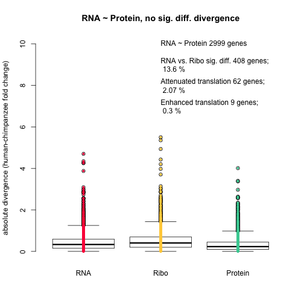

```r
ii_null_rnapro <- !(ii_rnaGTpro | ii_proGTrna)
ii_null_rnapro_riboAttenuated <- !(ii_rnaGTpro | ii_proGTrna) & ii_rnaGTribo
ii_null_rnapro_riboEnhanced <- !(ii_rnaGTpro | ii_proGTrna) & ii_riboGTrna

boxplot(abs(dmat_unnormed$rna[ii_null_rnapro]),
        abs(dmat_unnormed$ribo[ii_null_rnapro]),
        abs(dmat_unnormed$pro[ii_null_rnapro]),
        axes = F, ylim = c(0, 10))
axis(1, at = c(1,2,3), labels = c("RNA", "Ribo", "Protein"),
     col = "white")
axis(2)
points_cols <- c("Scarlet", "Sunglow", "Shamrock")
points(rep(1, sum(ii_null_rnapro)),
       abs(dmat_unnormed$rna[ii_null_rnapro]),
       pch = 19, cex = .5,
       col = crayon[points_cols[1]] )
points(rep(2, sum(ii_null_rnapro)),
       abs(dmat_unnormed$ribo[ii_null_rnapro]),
       pch = 19, cex = .5,
       col = crayon[points_cols[2]] )
points(rep(3, sum(ii_null_rnapro)),
       abs(dmat_unnormed$pro[ii_null_rnapro]),
       pch = 19, cex = .5,
       col = crayon[points_cols[3]] )
text(2, 10, adj = 0,
     label = paste("RNA ~ Protein", sum(ii_null_rnapro), "genes" ) )
text(2, 9, adj = 0,
     label = paste("RNA vs. Ribo sig. diff.",
       sum(ii_null_rnapro & (res.riborna$int.qval<.01)), "genes; \n",
       round(100*sum(ii_null_rnapro & (res.riborna$int.qval<.01))/
               sum(ii_null_rnapro), 2), "%") )
text(2, 8, adj = 0,
     label = paste("Attenuated translation",
       sum(ii_null_rnapro_riboAttenuated), "genes; \n",
       round(100*sum(ii_null_rnapro_riboAttenuated)/sum(ii_null_rnapro), 2), "%") )
text(2, 7, adj = 0,
     label = paste("Enhanced translation",
       sum(ii_null_rnapro_riboEnhanced), "genes; \n",
       round(100*sum(ii_null_rnapro_riboEnhanced)/sum(ii_null_rnapro), 2), "%") )
title(main = "RNA ~ Protein, no sig. diff. divergence",
      ylab = "absolute divergence (human-chimpanzee fold change)")
```

```r
# # Compute pairwise p-values between effect sizes of Ribo, RNA, and protein
# # among genes with RNA ~ Protein
# rna_ribo_t <- t.test( abs(dmat_unnormed$rna[ii_proNULLrna]),
#        abs(dmat_unnormed$ribo[ii_proNULLrna]), paired = TRUE )
# rna_pro_t <- t.test( abs(dmat_unnormed$rna[ii_proNULLrna]),
#        abs(dmat_unnormed$pro[ii_proNULLrna]), paired = TRUE )
# ribo_pro_t <- t.test( abs(dmat_unnormed$ribo[ii_proNULLrna]),
#        abs(dmat_unnormed$pro[ii_proNULLrna]), paired = TRUE )
#
# text(.5, 10, adj = 0,
#      label = paste("Paired t-test of effect sizes") )
# text(.5, 9, adj = 0,
#      label = paste("RNA vs. Ribo: p-value < 1e-14") )
# text(.5, 8, adj = 0,
#      label = paste("RNA vs. Protein: p-value < 1e-15") )
# text(.5, 7, adj = 0,
#      label = paste("Ribo vs. Protein: p-value < 1e-15") )
#
```

## Signal in RNA ~ Protein

Among the `408` genes with RNA and Ribo significant differences and no significant difference between RNA and protein, we do a follow-up analysis to look further to consider the contribution/relation of translation divergence to protein divergence, relative to RNA divergence.

Yoav: So, for example, if gene 1 (among the `408` genes with sig. diff. between RNA and Ribo) shows attenuated translation relative to RNA, protein divergence will be attenuated relative to RNA divergence. If gene 2 (among the `408` genes with sig. diff. between RNA and Ribo) shows enhanced ribo divergence compared with RNA, I predict that the protein divergence will also be enhanced compared with RNA.

```r
## RNA-Ribo enhancement or attenuation
ii_null_rnapro_riboAttenuated <- !(ii_rnaGTpro | ii_proGTrna) & ii_rnaGTribo
ii_null_rnapro_riboEnhanced <- !(ii_rnaGTpro | ii_proGTrna) & ii_riboGTrna

## RNA-Protein enhancement or attenuation
ii_null_rnapro_proAttenuated <-
    !(ii_rnaGTpro | ii_proGTrna) & (ii_sig_RNA_DE) &
    ( abs(xy.rnapro$rna) > abs(xy.rnapro$pro) |
      xy.rnapro$rna * xy.rnapro$pro < 0 )

ii_null_rnapro_proEnhanced <-
    !(ii_rnaGTpro | ii_proGTrna) & (ii_sig_RNA_DE) &
    ( abs(xy.rnapro$rna) < abs(xy.rnapro$pro) &
      (xy.rnapro$rna * xy.rnapro$pro > 0)  )

plot_mat <- matrix(0, 2, 2)
rownames(plot_mat) <- c("RNA-Ribo enhanced", "RNA-Ribo attenuated")
colnames(plot_mat) <- c("RNA-Protein enhanced", "RNA-Protein attenuated")

plot_mat[1,1] <- sum(ii_null_rnapro_riboEnhanced*ii_null_rnapro_proEnhanced)
plot_mat[1,2] <- sum(ii_null_rnapro_riboEnhanced*ii_null_rnapro_proAttenuated)
plot_mat[2,1] <- sum(ii_null_rnapro_riboAttenuated*ii_null_rnapro_proEnhanced)
plot_mat[2,2] <- sum(ii_null_rnapro_riboAttenuated*ii_null_rnapro_proAttenuated)

kable(plot_mat)
```

|  | RNA-Protein enhanced | RNA-Protein attenuated |
| --- | --- | --- |
| RNA-Ribo enhanced | 4 | 5 |
| RNA-Ribo attenuated | 1 | 61 |

### Attenuated translation

Among the `62` genes that were attenuated at the translation level relative to the transcript level (RNA-Ribo attenuation), we tested the null hypothesis that these genes are as likely to be attenuated as to be enhanced at the protein level relative to the transcript level (RNA-Protein). If this null hypothesis were rejected and the number of genes that were attenuated at the protein layer is larger than the number of genes that were enhanced at the protein layer, then we say that attenuation at the translation level is more likey to co-occur with attenuation at the protein level than with enhancement at the protein level.

```r
prop.test(plot_mat[2,2], rowSums(plot_mat)[2])
```

```r
##
##  1-sample proportions test with continuity correction
##
## data:  plot_mat[2, 2] out of rowSums(plot_mat)[2], null probability 0.5
## X-squared = 56.145, df = 1, p-value = 6.731e-14
## alternative hypothesis: true p is not equal to 0.5
## 95 percent confidence interval:
##  0.9016990 0.9991575
## sample estimates:
##        p
## 0.983871
```

### Enhanced translation

Among the `9` genes that were reinforced at translation, we tested the null hypothesis that these genes are as likely to be enhanced as to be attenuated at the protein layer. If this null hypothesis were rejected and the number of genes that were enhanced at the protein layer is more than those attenuated at the protein layer, then we say that genes that are enhanced at the translation level are more likely to be enhanced at the protein level than to be attenuated at the protein level.

```r
## One-proportion z-test
prop.test(plot_mat[1,1], rowSums(plot_mat)[1])
```

```r
##
##  1-sample proportions test with continuity correction
##
## data:  plot_mat[1, 1] out of rowSums(plot_mat)[1], null probability 0.5
## X-squared = 0, df = 1, p-value = 1
## alternative hypothesis: true p is not equal to 0.5
## 95 percent confidence interval:
##  0.1534306 0.7734708
## sample estimates:
##         p
## 0.4444444
```

```r
## Exact test of proportions (binomial test)
binom.test(plot_mat[1,1], rowSums(plot_mat)[1])
```

```r
##
##  Exact binomial test
##
## data:  plot_mat[1, 1] and rowSums(plot_mat)[1]
## number of successes = 4, number of trials = 9, p-value = 1
## alternative hypothesis: true probability of success is not equal to 0.5
## 95 percent confidence interval:
##  0.1369957 0.7879915
## sample estimates:
## probability of success
##              0.4444444
```

# RNA > Protein

Among the genes that are attenuated at the protein level compared to the RNA level (RNA > protein), we are interested in the number of genes with attenuated translation. In other words, we ask whether genes that were attenuated at the protein level were more likely to be enriched with genes attenuated at the translation level.

For the hypothesis testing, we computed number of genes enriched in translation attenuation among the genes enriched for protein attenuation in the set of `2999` with similar divergence levels between RNA and protein.

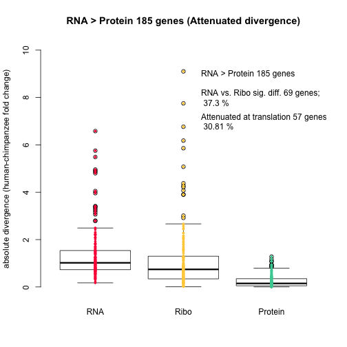

```r
boxplot(abs(dmat_unnormed$rna[ii_rnaGTpro]),
        abs(dmat_unnormed$ribo[ii_rnaGTpro]),
        abs(dmat_unnormed$pro[ii_rnaGTpro]),
        axes = F, ylim = c(0, 10))
axis(1, at = c(1,2,3), labels = c("RNA", "Ribo", "Protein"),
     col = "white")
axis(2)
points_cols <- c("Scarlet", "Sunglow", "Shamrock")
points(rep(1, sum(ii_rnaGTpro)), abs(dmat_unnormed$rna[ii_rnaGTpro]),
       pch = 19, cex = .5,
       col = crayon[points_cols[1]] )
points(rep(2, sum(ii_rnaGTpro)), abs(dmat_unnormed$ribo[ii_rnaGTpro]),
       pch = 19, cex = .5,
       col = crayon[points_cols[2]] )
points(rep(3, sum(ii_rnaGTpro)), abs(dmat_unnormed$pro[ii_rnaGTpro]),
       pch = 19, cex = .5,
       col = crayon[points_cols[3]] )
text(2.2, 9, adj = 0,
     label = paste("RNA > Protein", sum(ii_rnaGTpro),
                   "genes" ) )
text(2.2, 8, adj = 0,
     label = paste("RNA vs. Ribo sig. diff.",
      sum( ii_rnaGTpro*(res.riborna$int.qval<.01) ),
      "genes; \n",
      round( 100*sum(ii_rnaGTpro*(res.riborna$int.qval<.01) )/
            sum(ii_rnaGTpro), 2),"%") )
text(2.2, 7, adj = 0,
     label = paste("Attenuated at translation",
      sum( ii_rnaGTpro*ii_rnaGTribo ), "genes; \n",
      round( 100*sum(ii_rnaGTpro*ii_rnaGTribo)/sum(ii_rnaGTpro), 2),"%") )
title(main = paste("RNA > Protein",sum(ii_rnaGTpro),
                   "genes (Attenuated divergence)"),
      ylab = "absolute divergence (human-chimpanzee fold change)")
```

```r
## Null proportion of RNA-Protein attenuated | RNA-Ribo attenuated
rnapro_null_proAttenuated <- plot_mat[2, 2]/rowSums(plot_mat)[2]


prop.test( sum(ii_rnaGTpro*ii_rnaGTribo),
           sum(ii_rnaGTpro), p = rnapro_null_proAttenuated)
```

```r
##
##  1-sample proportions test with continuity correction
##
## data:  sum(ii_rnaGTpro * ii_rnaGTribo) out of sum(ii_rnaGTpro), null probability rnapro_null_proAttenuated
## X-squared = 5281.2, df = 1, p-value < 2.2e-16
## alternative hypothesis: true p is not equal to 0.983871
## 95 percent confidence interval:
##  0.2435541 0.3807825
## sample estimates:
##         p
## 0.3081081
```

```r
binom.test( sum(ii_rnaGTpro*ii_rnaGTribo),
           sum(ii_rnaGTpro), p = rnapro_null_proAttenuated)
```

```r
##
##  Exact binomial test
##
## data:  sum(ii_rnaGTpro * ii_rnaGTribo) and sum(ii_rnaGTpro)
## number of successes = 57, number of trials = 185, p-value <
## 2.2e-16
## alternative hypothesis: true probability of success is not equal to 0.983871
## 95 percent confidence interval:
##  0.2424438 0.3800427
## sample estimates:
## probability of success
##              0.3081081
```

# RNA < Protein

Among the genes that are enhanced at the protein level relative to the RNA level (RNA < Protein), we are interested in the number of genes that are enhanced at the translation level relative to the RNA level.

For the hypothesis testing, we computed number of genes enriched in translation reinforcement among the genes enriched for protein enhancement in the set of `2999` with similar divergence levels between RNA and protein.

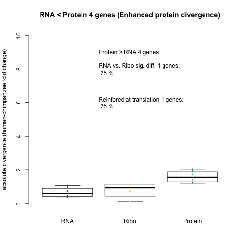

```r
boxplot(abs(dmat_unnormed$rna[ii_proGTrna]),
        abs(dmat_unnormed$ribo[ii_proGTrna]),
        abs(dmat_unnormed$pro[ii_proGTrna]),
        axes = F, ylim = c(0, 10))
axis(1, at = c(1,2,3), labels = c("RNA", "Ribo", "Protein"),
     col = "white")
axis(2)
points_cols <- c("Scarlet", "Sunglow", "Shamrock")
points(rep(1, sum(ii_proGTrna)), abs(dmat_unnormed$rna[ii_proGTrna]),
       pch = 19, cex = .5,
       col = crayon[points_cols[1]] )
points(rep(2, sum(ii_proGTrna)), abs(dmat_unnormed$ribo[ii_proGTrna]),
       pch = 19, cex = .5,
       col = crayon[points_cols[2]] )
points(rep(3, sum(ii_proGTrna)), abs(dmat_unnormed$pro[ii_proGTrna]),
       pch = 19, cex = .5,
       col = crayon[points_cols[3]] )
text(1.5, 9, adj = 0,
     label = paste("Protein > RNA", sum(ii_proGTrna), "genes" ) )
text(1.5, 8, adj = 0,
     label = paste("RNA vs. Ribo sig. diff.",
       sum( ii_proGTrna*(res.riborna$int.qval<.01) ), "genes; \n",
       round(100*sum( ii_proGTrna*(res.riborna$int.qval<.01) )/
             sum(ii_proGTrna), 2), "%") )
text(1.5, 6, adj = 0,
     label = paste("Reinfored at translation",
      sum(ii_proGTrna*ii_riboGTrna), "genes; \n",
      round(100*sum(ii_proGTrna*ii_riboGTrna)/sum(ii_proGTrna),
            2),"%") )
title(main = paste("RNA < Protein",sum(ii_proGTrna),
                  "genes (Enhanced protein divergence)"),
      ylab = "absolute divergence (human-chimpanzee fold change)")
```

```r
## Null proportion of RNA-Ribo enhanced | RNA-Protein enhanced
rnapro_null_proEnhanced <- plot_mat[1, 1]/rowSums(plot_mat)[1]

prop.test( sum(ii_proGTrna*ii_riboGTrna),
           sum(ii_proGTrna), p = rnapro_null_proEnhanced)
```

```r
##
##  1-sample proportions test with continuity correction
##
## data:  sum(ii_proGTrna * ii_riboGTrna) out of sum(ii_proGTrna), null probability rnapro_null_proEnhanced
## X-squared = 0.078125, df = 1, p-value = 0.7799
## alternative hypothesis: true p is not equal to 0.4444444
## 95 percent confidence interval:
##  0.01319116 0.78057348
## sample estimates:
##    p
## 0.25
```

```r
binom.test( sum(ii_proGTrna*ii_riboGTrna),
           sum(ii_proGTrna), p = rnapro_null_proEnhanced)
```

```r
##
##  Exact binomial test
##
## data:  sum(ii_proGTrna * ii_riboGTrna) and sum(ii_proGTrna)
## number of successes = 1, number of trials = 4, p-value = 0.6342
## alternative hypothesis: true probability of success is not equal to 0.4444444
## 95 percent confidence interval:
##  0.006309463 0.805879550
## sample estimates:
## probability of success
##                   0.25
```

Styled with knitrBootstrap